# Ensemble Methods

## 2. Number of features ($m_{try}$).

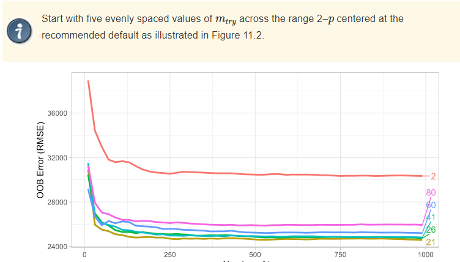

- $m_{try}$ helps to balance low tree correlation with reasonable predictive strength.
- Sensitive to total number of variables. If high /low, better increase/decrease it.

## 3. Complexity of each tree.

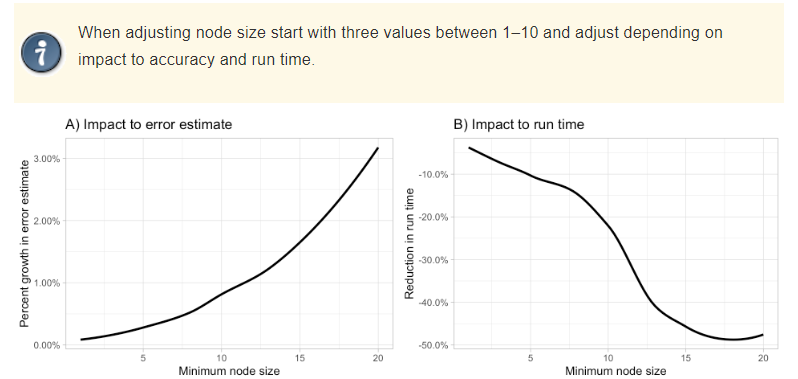

- The complexity of underlying trees influences RF performance.
- Node size has strong influence on error and time.

## 4. Sampling scheme.

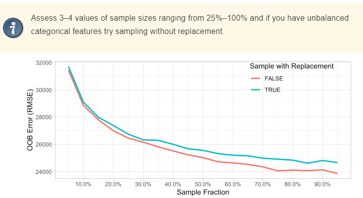

- Default: Bootstrap sampling with replacement on 100% observations.
- Sampling fraction and replacement strategy influence diversity and prediction error.

## 5. Splitting rule

- *Default splitting rules* favor features with many splits, potentially biasing towards certain variable types.
- *Conditional inference trees* offer an alternative to reduce bias, but may not always improve predictive accuracy and have longer training times.
- *Randomized splitting rules*, like *extremely randomized trees* (which draw split points completely randomly), improve computational efficiency but may not enhance predictive accuracy and can even reduce it.

## Tuning hyperparameters

- RF are a good example of a common situachion in ML:
  - As the number of parameter increases,
  - finding their optimal values requires more effort
  - and can even become computationally unfeasible.
- As more complex algorithms with greater number of hyperparameters are introduced tuning strategies should also be considered.

## Tuning strategies

- **Grid Search**: Systematically searches through (*all possible combinations*) a predefined grid of hyperparameter values to find the combination that maximizes performance.
- **Random Search**: Randomly samples hyperparameter values from predefined distributions. Faster than Grid Search, but less prone to find optimum.
- **Model-Based Optimization** leverages probabilistic models, often Gaussian processes, to model the objective function and iteratively guide the search for optimal hyperparameters.

## Random forests in bioinformatics

- Random forests have been thoroughly used in Bioinformatics (Boulesteix et al. 2012).
- Bioinformatics data are often high dimensional with
  - dozens or (less often) hundreds of samples/individuals
  - thousands (or hundreds of thousands) of variables.

## Application of Random forests

- Random forests provide robust classifiers for:
  - Distinguishing cancer from non cancer,
  - Predicting tumor type in cancer of unknown origin,
  - Selecting variables (SNPs) in Genome Wide Association Studies…
- Some variation of Random forests are used only for variable selection

# Boosting

## Improving predictors iteratively

- The idea of *improving weak learners by aggregation* has moved historically along two distinct lines:
  1. Build similar learners on resamples from the original sample and average the predictions.
  - This entails *Bagging* and *Random Forests*
  2. Build a learner progressively, improving it at every step using weak learners, until the desired possible quality is obtained.
  - This is what *Boosting* is about.

## Bagging vs Boosting

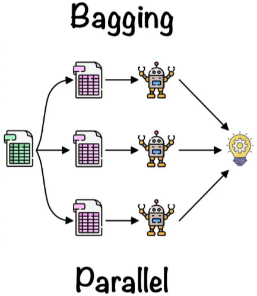

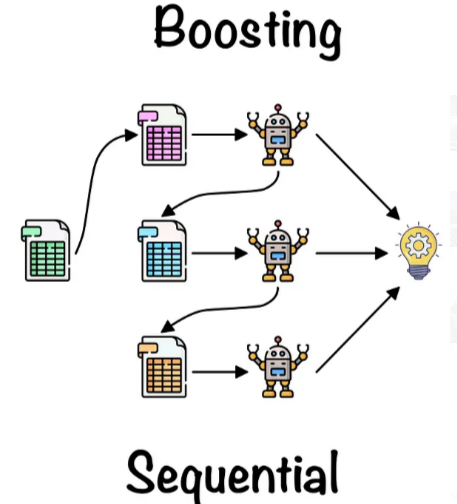

Source: [Ensemble Learning: Bagging & Boosting](https://resources.experfy.com/ai-ml/ensemble-learning-bagging-boosting/)

## So bagging or boosting?

- Bagging/RF improves predictive performance by reducing **variance**.
  - *Averaging many unstable models* may produce a predictor with **smaller variance**.
- Averaging does not necessarily solve problems caused by **high bias**.
  - If individual models systematically underfit the data, averaging many of them may still produce an underfitted predictor.
  - Boosting aims to reduce **bias** by progressively improving the predictor.

## A sequential correction

Boosting follows the following strategy:

- Models are built sequentially,
- Each new model attempts to correct errors made by previous ones.

Boosting constructs an additive model:
$$F(x) = f_1(x)+f_2(x)+f_3(x)+\dots$$

- $f_1(x)$ captures the main structure of the data,
- $f_2(x)$ corrects part of the remaining errors,
- $f_3(x)$ corrects the residual errors left
- and so on.

Final predictor is built incrementally through a sequence of weak learners.

## General idea of Boosting

Boosting transforms many weak learners into a strong learner through *sequential error correction*.

1. It trains an initial weak learner.
2. Evaluates its errors.
3. Trains a new learner focused on correcting those errors.
4. Adds the new learner to the ensemble.
5. Repeats the process iteratively.

## Boosting variants

- Different Boosting algorithms have been developed.
- They mainly differ in:
  - how the errors are defined and,
  - how next learner is constructed to reduce them.
- This leads to different Boosting methods such as:
  - AdaBoost,
  - Gradient Boosting,
  - XGBoost,
  - LightGBM.

## AdaBoost

- It proceeds **Ada**ptatively by sequentially training weak,learners.
- Each new learner focuses increasingly on the difficult observations.
  - observations that are difficult to classify receive more attention,
  - while observations already classified correctly become less important.
- Final prediction combines all weak learners using a weighted vote.

## Running Adaboost

At each iteration AdaBoost performs four main steps:

1. Fit a weak learner using the current observation weights.
2. Evaluate which observations are misclassified.
3. Increase the weights of difficult observations.
4. Assign a reliability weight to the learner itself.

As iterations proceed:

- difficult observations receive more attention,
- and accurate learners receive more influence in the final prediction.

The final classifier is therefore a weighted combination of weak learners.

## Why do learner weights appear?

Initially, all observations receive the same weight, $w_i=\frac{1}{N}$

AdaBoost gives more influence to learners that achieve better classification performance.

If a learner has weighted error rate, $\epsilon_t$, its contribution to the final ensemble is determined by:
$$\alpha_t=\frac{1}{2}\log\left(\frac{1-\epsilon_t}{\epsilon_t}\right)$$

Consequently:

- highly accurate learners receive larger weights,
- learners close to random guessing receive very small weights.

The final prediction is therefore dominated by the most reliable classifiers.

## Adaboost Architecture

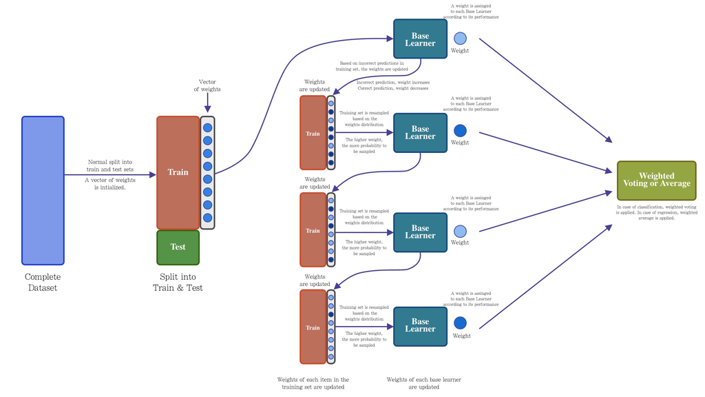

Source: [Ensemble Learning: Bagging & Boosting](https://resources.experfy.com/ai-ml/ensemble-learning-bagging-boosting/)

## Adaboost applications

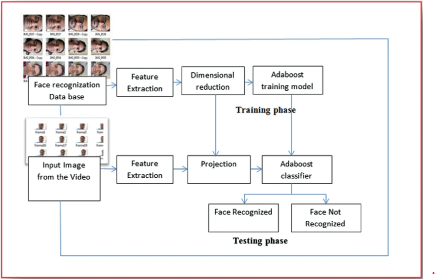

source: [Evaluating the AdaBoost Algorithm for Biometric-Based Face Recognition](https://doi.org/10.1007/978-981-16-0081-4_67)

## AdaBoost as loss minimization (1)

- AdaBoost is often presented as a heuristic algorithm,
- But it is also an optimization procedure: It can be shown to minimize the exponential loss:
  $$L(y,F(x))=e^{-yF(x)}$$

where:

- $y \in \{-1,+1\}$,
- and $F(x)$ is the additive ensemble model.

## Adaboost as loss minimization (2)

- The interpretation described above is important because it shows that *AdaBoost is not simply an arbitrary reweighting strategy*.
- Instead, AdaBoost can be understood as
  - a sequential optimization procedure that
  - incrementally builds an additive predictive model
  - by reducing a **specific** loss function.
- This connects AdaBoost with the more general framework of Gradient Boosting where more general loss functions can be minimized.

## Moving beyond AdaBoost

AdaBoost introduced the key idea of sequentially improving weak learners.

But it has important limitations:

- Originally designed mainly for classification,
- It relies on a specific exponential loss,
- It can become sensitive to noisy observations and outliers.

This motivated the development of a more general framework:

- instead of designing specific reweighting rules,
- directly minimize a loss function through iterative optimization.

This idea leads to Gradient Boosting.

## Gradient Boosting

- Developed to overcome the limitations of Adaboost.
- Takes a different approach that can be linked with Optimization by Gradient Descent.
- Several advantages over Adaboost
  - Can handle continuous variables much better,
  - It is more robust to noisy data and outliers.
  - Can handle complex datasets and
  - Can continue to improve its accuracy even after Adaboost’s performance has “plateaued”.

## A function optimization

Gradient Boosting views learning as an optimization problem.

Instead of directly searching for a single complex predictor, the model is *built incrementally* as:

$$F_M(x)=F_{M-1}(x)+\gamma_M h_M(x)$$

where:

- $F_{M-1}(x)$ is the current ensemble,
- $h_M(x)$ is a new weak learner,
- and $\gamma_M$ controls how much the new learner contributes.

At each iteration, the algorithm searches for the weak learner that most reduces the current loss function.

The final model is constructed through a sequence of small corrective updates.

## Relation with Gradient Descent

In gradient descent optimization, parameters are updated in the direction that most decreases the loss function:

$$\theta_{new}=\theta_{old}-\eta\nabla L$$

Gradient Boosting *applies the idea to predictive functions*.

Instead of updating numerical parameters the algorithm *updates the prediction function itself*.

At each iteration, a new weak learner is fitted to approximate the direction of steepest loss reduction.

## Residual fitting as a special case

- For squared error loss, {$L(y,F(x))=(y-F(x))^2$ } the negative gradient becomes: {$-\partial{L}/\partial{F}=y-F(x)$}, which *corresponds exactly to the residuals*.
- Therefore, for least-squares regression, fitting the negative gradient, and fitting the residuals, are equivalent procedures.
- This explains why Gradient Boosting is often described as “iteratively fitting residuals”.
- However, for other loss functions the negative gradient is no longer the residual, and Gradient Boosting provides a much more general framework.

## Gradient Boosting algorithm

1. Initialize model with constant prediction, $F_0(x)$.
2. For each iteration $m=1,\dots,M$:
   1. Compute the negative gradient of the loss function.
   2. Fit a weak learner $h_m(x)$ to the negative gradient.
   3. Find the optimal step size:$\gamma_m$.
   4. Update the ensemble
      $$F_m(x)=F_{m-1}(x)+\gamma_m h_m(x)$$
3. Output the final ensemble model.

## Gradient Boosting pseudo-code

1. Initialize the model with a constant value: $f_0(x) = \frac{1}{n} \sum\limits_{i=1}^{n} y_i$
2. For $t = 1$ to $T$:
   1. Compute the negative gradient of the loss function at the current fit: $r_{ti} = -\frac{\partial L(y_i, f_{t-1}(x_i))}{\partial f_{t-1}(x_i)}$
   2. Train a new model to predict the negative gradient values: $h(x; \theta_t) = \arg\min\limits_{h} \sum\limits_{i=1}^{n} (r_{ti} - h(x_i; \theta))^2$
   3. Compute the optimal step size: $\gamma_t = \arg\min\limits_{\gamma} \sum\limits_{i=1}^{n} L(y_i, f_{t-1}(x_i) + \gamma h(x_i; \theta_t))$
   4. Update the model: $f_t(x) = f_{t-1}(x) + \gamma_t h(x; \theta_t)$
3. Output the final model: $F(x) = f_T(x)$

## Gradient boosting architechture

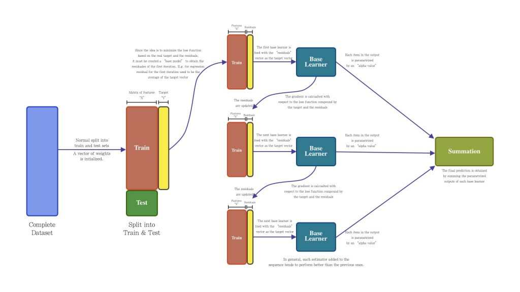

Source: [Ensemble Learning: Bagging & Boosting](https://resources.experfy.com/ai-ml/ensemble-learning-bagging-boosting/)

## Advantages of Boosting

- Boosting, like other Ensemble methods, improves the accuracy of weak learners and achieve better predictive performance than individual models.
- Boosting also reduces overfitting by improving the generalization ability of models.
- Available in many flavors,
- Strong experience in Real world applications and industry.

## Limitations of Boosting

- Can be computationally expensive, especially when dealing with large datasets and complex models.
- Can be sensitive to noisy data and outliers,
- May not work well with certain types of data distributions.
- Not so good as “out-of-the-box”: Requires careful tuning of hyperparameters to achieve optimal performance, which can be time-consuming and challenging.

## Boosting application with R and Python

- Many R packages implement the many variations of boosting:
  - ada,
  - [adabag](https://cran.r-project.org/web/packages/ada),
  - mboost,
  - gbm,
  - [xgboost](https://github.com/dmlc/xgboost/tree/master/R-package)
  - An interesting option is to rely on the [caret](https://cran.r-project.org/web/packages/caret/index.html) package which allows to run the distinct methods with a common interface.
- In Python we usually rely on scikit-learn libraries although there are many alternative implementations
  - [Scikit-learn ensemble](https://scikit-learn.org/stable/modules/ensemble.html)
  - https://python-course.eu/machine-learning/boosting-algorithm-in-python.php

## References

# Appendix I: The Bootstrap

These slides have been conserved as an appendix because they were originally added to this chapter, when a section on resampling was not included in previous chapters.

They can be used as an introduction to the bootstrap, similar to the scond part of the Chapter on Cross-validation and resampling.

## The bootstrap

- *Bootstrap* methods were introduced by Efron (1979) to estimate the standard error of a statistic.
- The success of the idea lied in that the procedure was presented as *automatic*, that is:
  - instead of having to do complex calculations,
  - it allowed to approximate them using computer simulation.
- Some called it *the end of mathematical statistics*.

## Bootstrap Applications

- The bootstrap has been applied to almost any problem in Statistics.
  - Computing standard errors, Bias, Quantiles,
  - Building Confidence intervals,
  - Doing Significance tests, …
- We illustrate it with the simplest case: *estimating the standard error of an estimator*.

## Empirical Distribution Function

- Let $X$ be a random variable with distribution function $F$,
- Let $\mathbf{X}=X_1,\ldots,X_n$ be an i.i.d random sample of $F$ and,
- let $x_1,\dots, x_n$ be a realization of $\mathbf{X}$.
- The *Empirical Cumulative Distribution Function (ECDF)*
  $$F_n(x) = \frac{1}{n} \#\{x_i\le x: i=1\dots n\} = \frac{1}{n}
  \sum_{i=1}^n I_{(-\infty,x]}(x_i),$$
  is the function that assigns to each real number $x$ the proportion of observed values that are less or equal than $x$.

## The ECDF in R

```r
x<- c(2,5,0,11,-1)
Fn <- ecdf(x)
knots(Fn)
```

```
[1] -1  0  2  5 11
```

```r
cat("Fn(3) = ", Fn(3))
```

```
Fn(3) =  0.6
```

```r
cat("Fn(-2) = ", Fn(-2))
```

```
Fn(-2) =  0
```

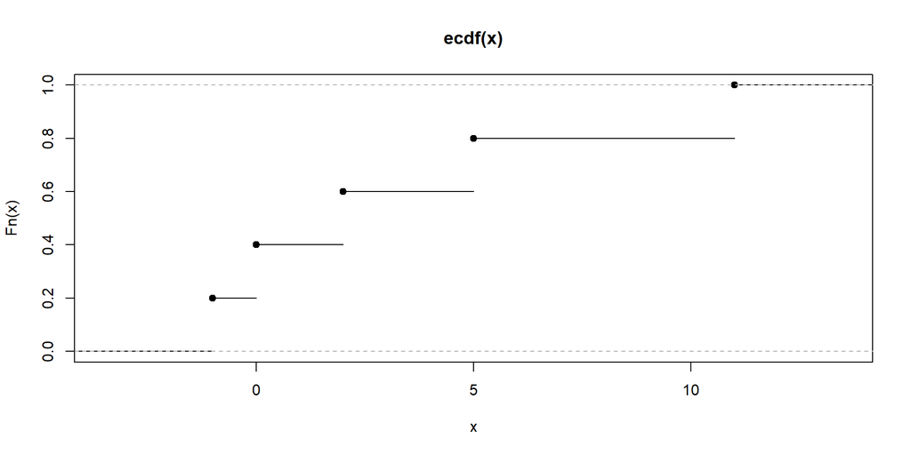

```r
plot(Fn)
```

## ECDF has good properties

- $F_n (x)$ is a cumulative distribution function.
- $F_n()$ is an important DF because it comes to be *the best approximation that one can find for the theoretical (population) distribution function*, that is:
  $$F_n(x) \longrightarrow F(x), \text { uniformly in } x \text{ as } n \rightarrow \infty.$$
- This is stated in the Glivenko-Cantelli theorem also know as the *Central Theorem of Statistics*.

## The Sample distribution function

- Given a sample, $\mathbf{X}$ from a certain distribution, $X$,
- Consider it a discrete random variable $X_e$ that sets mass $1/n$ to each of the observed $n$ points $x_i$:

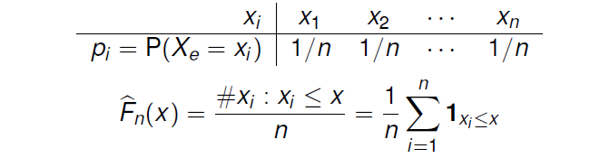

- $F_n$ is the distribution (function) of $X_e$.
- From here, we notice that *generating samples from $F_n$ can be done by randomly taking values from $\mathbf{X}$ with probability $1/n$*

## Plug-in estimators

- Assume we want to estimate some parameter $\theta$, that can be expressed as $\theta (F)$, where $F$ is the distribution function of each $X_i$ in $(X_1,X_2,...,X_n)$.
- For example, $\theta = E_F(X)=\theta (F)$.
- A *natural* way to estimate $\theta(F)$ may be to rely on *plug-in estimators*, where $F$ in $\hat \theta (F)$ is substituted by some approximation (estimate) to $F$.

## Plug-in estimators

- A plug-in estimator is obtained by substituting $F$ by an approximation to $F$, call it $\hat F$ in $\theta(F)$:
  $$\widehat {\theta (F)}=\theta(\hat{F})$$
- Given that $F_n$ is the best approximation to $F$ a reasonable plug-in estimator is $\theta(F_n)$.
- Common sample estimators are, indeed, plug-in estimators.

## Some plug-in estimators

- Many estimators we usally work with are plug-in estimators.

$$\begin{eqnarray*}
\theta_1 &=& E_F(X)=\theta (F) \\
\hat{\theta_1}&=&\overline{X}=\int XdF_n(x)=\frac
1n\sum_{i=1}^nx_i=\theta (F_n)
\\
\theta_2 &=& Med(X)=\{m:P_F(X\leq m)=1/2\}=
\theta (F),
\\
\hat{\theta_2}&=&\widehat{Med}(X)=\{m:\frac{\#x_i\leq m}n=1/2\}=\theta (F_n)
\end{eqnarray*}$$

## Precision of an estimate

- A key point, when computing an estimator $\hat \theta$ of a parameter $\theta$, is how precise is $\hat \theta$ as an estimator of $\theta$?
  - With the sample mean, $\overline{X}$, the standard error estimation is immediate because the variance of the estimator is known: $\sigma_{\overline{X}}=\frac{\sigma (X)}{\sqrt{n}}$
  - So, a natural estimator of the standard error of $\overline{X}$ is: $\hat\sigma_{\overline{X}}=\frac{\hat{\sigma}(X)}{\sqrt{n}}$

## Precision of an estimate (2)

- If, as in this case, the variance of $X$ (and, here, that of $\overline{X}$) is a functional of $F$:

$$\sigma _{\overline{X}}=\frac{\sigma (X)}{\sqrt{n}}=\frac{\sqrt{\int
[x-\int x\,dF(x)]^2 dF(x)}}{\sqrt{n}}=\sigma _{\overline{X}}(F)$$

then, the standard error estimator is the same functional applied on $F_n$, that is:

$$\hat{\sigma}_{\overline{X}}=\frac{\hat{\sigma}(X)}{\sqrt{n}}=\frac{\sqrt{1/n\sum_{i=1}^n(x_i-\overline{x})^2}}{\sqrt{n}}=\sigma
_{\overline{X}}(F_n).$$

## Standard error estimation

- Thus, a way to obtain a standard error estimator $\widehat{\sigma}_{\widehat{\theta}}$ of an estimator $\widehat{\theta}$ consists on replacing $F$ with $F_n$ in the ``population’’ standard error expression of $\hat \theta$, $\displaystyle{\sigma_{\hat \theta}= \sigma_{\hat \theta}(F)}$, **whenever it is known**.
- In a schematic form:
  $$\sigma_{\hat \theta}= \sigma_{\hat \theta}(F) \Longrightarrow
  \sigma_{\hat \theta}(F_n)= \widehat{\sigma}_{\hat \theta}.$$
  That is, *the process consists of “plugging-in” $F_n$ in the (known) functional form, $\sigma_{\hat \theta}(F)$ that defines $\sigma_{\hat \theta}$}*.

## The bootstrap (1)

- The previous approach, $F\simeq F_n \Longrightarrow \sigma_{\hat \theta}(F) \simeq \sigma_{\hat \theta}(F_n)$ presents the obvious drawback that, when the functional form $\sigma _{\hat{\theta}}(F)$ is unknown, it is not possible to carry out the substitution of $F$ by $F_n$.
- This is, for example, the case of standard error of the median or [that of the correlation coefficient](http://artent.net/2012/07/31/standard-deviation-of-sample-median/).

## The bootstrap (2)

- The *bootstrap* method makes it possible to do the desired approximation:
  $$\hat{\sigma}_{\hat\theta} \simeq \sigma _{\hat\theta}(F_n)$$
  *without having to to know the form of* $\sigma_{\hat\theta}(F)$.
- To do this,*the bootstrap estimates, or directly approaches* $\sigma_{\hat{\theta}}(F_n)$ *over the sample*.

## Bootstrap sampling (*resampling*)

- The *bootstrap* allows to estimate the standard error from samples of $F_n$

$$\begin{eqnarray*}
&&\mbox{Instead of: } \\
&& \quad F\stackrel{s.r.s}{\longrightarrow }{\bf X} =
(X_1,X_2,\dots, X_n) \, \quad (\hat \sigma_{\hat\theta} =\underbrace{\sigma_{\theta(F_n)}_{unknown})
\\
&& \mbox{It is done: } \\
&& \quad F_n\stackrel{s.r.s}{\longrightarrow }\quad {\bf X^{*}}=(X_1^{*},X_2^{*},
\dots ,X_n^{*}) \\
&& \quad (\hat \sigma_{\hat\theta}= \hat \sigma_{\hat \theta}^* \simeq \sigma_{\hat \theta}^*=\sigma_{\hat \theta}(F_n)).
\end{eqnarray*}$$

## The resampling process

- Resampling consists of *extracting samples of size $n$ of $F_n$*: ${\bf X_b^{*}}$ is a random sample of size $n$ obtained *with replacement* from the original sample ${\bf X}$.
- Samples ${\bf X^*_1, X^*_2, ..., X^*_B }$, obtained through this procedure are called *bootstrap* samples or *re-samples*.
- On each resample the statistic of interest $\hat \theta$ can be computed yielding a *bootstrap estimate* $\hat \theta^*_b= s(\mathbf{x^*_b})$.
- The collection of bootstrap estimates obtained form the resampled samples can be used to estimate distinct characteristics of $\hat \theta$ such as its standard error, its bias, etc.

## Resampling illustrated

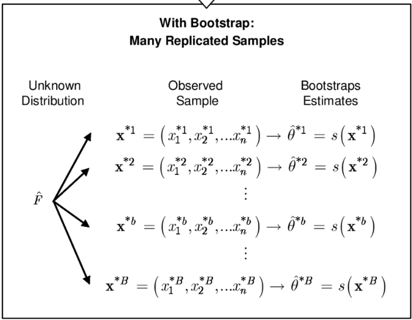

## The bootstrap distribution

- The distribution of a statistic computed from re-samples is called the *bootstrap distribution*,

$$\begin{eqnarray*}
\mathcal {L}(\hat \theta)&\simeq& P_F(\hat\theta \leq t): \mbox{Sampling distribution of } \hat \theta,\\
\mathcal {L}(\hat \theta^*)&\simeq& P_{F_n}(\hat\theta^* \leq t): \mbox{Bootstrap distribution of } \hat \theta,
\end{eqnarray*}$$

- This distribution is usually not known.
- However the sampling process and the calculation of the statistics can be approximated using a Monte Carlo Algorithm.

## Boot. Monte Carlo Algorithm

1. Draw a bootstrap sample, ${\bf x}_1^{*}$ from $F_n$ and compute $\hat{\theta}({\bf x}_1^{*})$.
2. Repeat (1) $B$ times yielding $\hat{\theta}({\bf x}_2^{*})$, $\dots$, $\hat{\theta}({\bf x}_B^{*})$ estimates.
3. Compute:
   $$\begin{equation*}
   \hat{\sigma}_B (\hat\theta)= \sqrt{
   \frac{
   \sum_{b=1}^B\left( \hat{\theta}(%
   {\bf x^{*}_i})-\overline{\hat{\theta}^*}\right) ^2
   }{
   (B-1)
   }
   }, \quad \overline{\hat{\theta}^*}\equiv \frac 1B\sum_{b=1}^B\hat{\theta}\left( {\bf x}%
   _b^{*}\right)
   \end{equation*}$$

## Bootstrap Estimates of SE

- Idea behind the bootstrap: the standard error of $\hat\theta$, $\sigma(\hat\theta)$ can be *approximated* by the bootstrap estimator of the standard error, $\sigma_B (\hat\theta)$ which:
  - Coincides with $\sigma_{\hat\theta}(F_n)$, that cannot be evaluated, if the functional form of $\sigma_{\hat\theta}(F)$ is unkown.
  - Can be approximated by the Monte Carlo Estimator, $\hat\sigma_{\hat\theta}(F_n)$, which is evaluated by resampling.

$$\hat{\sigma}_B(\hat\theta)\left (\simeq \sigma_B(\hat\theta)=\sigma_{\hat\theta}(F_n)\right )\simeq\hat \sigma_{\hat\theta}(F_n).$$

## Summary

From real world to *bootstrap* world:

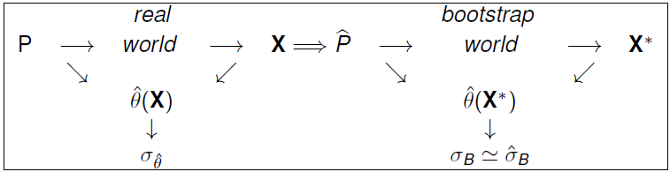

Bishop, Christopher M. 2007. *Pattern Recognition and Machine Learning (Information Science and Statistics)*. 1st ed. Springer. http://www.amazon.com/Pattern-Recognition-Learning-Information-Statistics/dp/0387310738%3FSubscriptionId%3D13CT5CVB80YFWJEPWS02%26tag%3Dws%26linkCode%3Dxm2%26camp%3D2025%26creative%3D165953%26creativeASIN%3D0387310738.

Boehmke, Bradley, and Brandon Greenwell. 2020. *The r Series Hands-on Machine Learning with r*. *CRC Press*. https://www.routledge.com/Hands-On-Machine-Learning-with-R/Boehmke-Greenwell/p/book/9781138495685.

Boulesteix, Anne Laure, Silke Janitza, Jochen Kruppa, and Inke R. König. 2012. “Overview of Random Forest Methodology and Practical Guidance with Emphasis on Computational Biology and Bioinformatics.” *Undefined* 2 (November): 493–507. https://doi.org/10.1002/WIDM.1072.

Breiman, Leo. 1996. “Bagging Predictors.” *Machine Learning* 24: 123–40. https://doi.org/10.1007/BF00058655/METRICS.

Efron, B. 1979. “Bootstrap Methods: Another Look at the Jackknife.” *The Annals of Statistics* 7 (1): 1–26. https://doi.org/10.1214/aos/1176344552.

Probst, Philipp, Marvin N. Wright, and Anne-Laure Boulesteix. 2019. “Hyperparameters and Tuning Strategies for Random Forest.” *WIREs Data Mining and Knowledge Discovery* 9 (3): e1301. https://doi.org/https://doi.org/10.1002/widm.1301.